# Scraping, geocoding and emailing

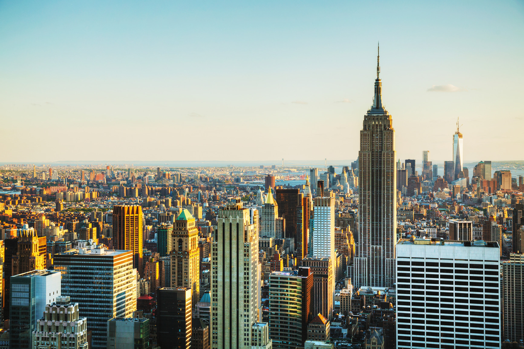

Find me on twitter: LudoBenistant

# 1 Introduction

At work, we all need **relevant information delivered in a timely manner** and data science can help to do that. Here is a brief example of a short and useful program.

Let’s say our partners (more than 100) want to know when and **where interesting events will happen near their location**. Of course, we want them to attend these events because it will raise their awareness of the latest technology and develop their local business network.

So we write a code that **(1) find the relevant event** with the time and location, **(2) add on the world map the location** of these events, **(3) send this information per email**. This program could be easily rerun automatically every months.

**Library needed:**

```r
library(plyr)
library(dplyr)
library(rvest)
library(stringr)
library(DT)
```

# 2 Scraping

For the sake of the example let’s take the events listed on this website: [www.eventbrite.ca](https://www.eventbrite.ca/d/canada--toronto/startup-conference/). We select the event name, time and location. We also clean each string using the stringr library.

## 2.1 Event Title

```r
startup_events <- read_html("https://www.eventbrite.ca/d/canada--toronto/startup-conference/")

# Event name
events_title <- startup_events %>%
  html_nodes(".list-card__title") %>%
  html_text()

# Clean
events_title <- str_trim(events_title)
events_title
```

```
##  [1] "Empire Startups FinTech Conference"
##  [2] "LATAM STARTUPS CONFERENCE - Early bird"
##  [3] "Startup Grind 2017 Global Conference"
##  [4] "#FinTechTO"
##  [5] "StartupTech Unleashed Meetup: Toronto - September 2016"
##  [6] "Neil Patel Presents: Growth Hacking Tactics for 2017 [Virtual Event]"
##  [7] "MLX: Machine Learning Fintech Conference"
##  [8] "RIC Centre Expert Speaker Series: Startup Guide to Funding Regulations"
##  [9] "StartupTech Unleashed Meetup: Kitchener/Waterloo-August 2016"
## [10] "Scaling Your Business"
## [11] "Fireside Conference 2016"
## [12] "Industry 2016 | The Product Conference"
## [13] "Upstate Unleashed Conference & 2016 Venture Ecosystem Awards"
## [14] "2016 Brand Camp Summit Detroit: Humans & Cities-Building Brands that Matter"
## [15] "DevOpsDays Detroit 2016"
## [16] "THE PITCH"
```

## 2.2 Time

```r
# Event time
events_time <- startup_events %>%
  html_nodes("time") %>%
  html_text()

# Clean
events_time <- str_trim(events_time)
events_time
```

```
##  [1] "Mon, 7 Nov\n                    8:00 AM"
##  [2] "Wed, 27 Jul\n                    6:00 AM"
##  [3] "Tue, 14 Feb\n                    8:30 AM"
##  [4] "Thu, 18 Aug\n                    8:00 AM"
##  [5] "Tue, 6 Sep\n                    6:30 PM"
##  [6] "Mon, 17 Oct\n                    10:30 AM"
##  [7] "Wed, 26 Oct\n                    8:30 AM"
##  [8] "Wed, 7 Sep\n                    12:00 PM"
##  [9] "Tue, 30 Aug\n                    6:30 PM"
## [10] "Tue, 13 Sep\n                    1:00 PM"
## [11] "Fri, 9 Sep\n                    12:00 PM"
## [12] "Thu, 15 Sep\n                    9:00 AM"
## [13] "Fri, 16 Sep\n                    8:30 AM"
## [14] "Tue, 13 Sep\n                    9:00 AM"
## [15] "Wed, 12 Oct\n                    9:00 AM"
## [16] "Fri, 12 Aug\n                    3:15 PM"
```

## 2.3 Location

```r
# Event location
events_location <- startup_events %>%
  html_nodes(".list-card__venue") %>%
  html_text()

# Clean
events_location <- str_trim(events_location)
events_location
```

```
##  [1] "The Regency Ballroom"
##  [2] ""
##  [3] "Fox Theater"
##  [4] "Arcadian Court"
##  [5] "Verkspace"
##  [6] "Toronto"
##  [7] "University of Toronto - St. George Campus"
##  [8] "Xerox Research Centre of Canada (Pake Auditorium)"
##  [9] "Waterloo Public Library"
## [10] "The Strathallan Rochester - a DoubleTree by Hilton Hotel"
## [11] "Camp Walden"
## [12] "Music Box, The Flats, Downtown Cleveland"
## [13] "Turning Stone Resort"
## [14] "Detroit Center for Design + Technology (Brand Camp University Detroit Campus)"
## [15] "The College for Creative Studies, A. Alfred Taubman Center for Design Education"
## [16] "The Westin Ottawa"
```

## 2.4 Results

```r
# create a data frame with all this element as varibles
Events_df = data.frame(events_title, events_time, events_location)
datatable(Events_df)
```

|  | events_title | events_time | events_location |
| --- | --- | --- | --- |
| 1 | Empire Startups FinTech Conference | Mon, 7 Nov 8:00 AM | The Regency Ballroom |
| 2 | LATAM STARTUPS CONFERENCE - Early bird | Wed, 27 Jul 6:00 AM |  |
| 3 | Startup Grind 2017 Global Conference | Tue, 14 Feb 8:30 AM | Fox Theater |
| 4 | #FinTechTO | Thu, 18 Aug 8:00 AM | Arcadian Court |
| 5 | StartupTech Unleashed Meetup: Toronto - September 2016 | Tue, 6 Sep 6:30 PM | Verkspace |
| 6 | Neil Patel Presents: Growth Hacking Tactics for 2017 [Virtual Event] | Mon, 17 Oct 10:30 AM | Toronto |
| 7 | MLX: Machine Learning Fintech Conference | Wed, 26 Oct 8:30 AM | University of Toronto - St. George Campus |
| 8 | RIC Centre Expert Speaker Series: Startup Guide to Funding Regulations | Wed, 7 Sep 12:00 PM | Xerox Research Centre of Canada (Pake Auditorium) |
| 9 | StartupTech Unleashed Meetup: Kitchener/Waterloo-August 2016 | Tue, 30 Aug 6:30 PM | Waterloo Public Library |
| 10 | Scaling Your Business | Tue, 13 Sep 1:00 PM | The Strathallan Rochester - a DoubleTree by Hilton Hotel |

[output cut: 6 more lines]

# 3 Geocoding

Load library:

```r
library(ggmap)
library(leaflet)
library(RColorBrewer)
```

Set the variable as characters

```r
# set as characters
Events_df$events_title <- as.character(Events_df$events_title)
Events_df$events_time <- as.character(Events_df$events_time)
Events_df$events_location <- as.character(Events_df$events_location)
str(Events_df)
```

```
## 'data.frame':    16 obs. of  3 variables:
##  $ events_title   : chr  "Empire Startups FinTech Conference" "LATAM STARTUPS CONFERENCE - Early bird" "Startup Grind 2017 Global Conference" "#FinTechTO" ...
##  $ events_time    : chr  "Mon, 7 Nov\n                    8:00 AM" "Wed, 27 Jul\n                    6:00 AM" "Tue, 14 Feb\n                    8:30 AM" "Thu, 18 Aug\n                    8:00 AM" ...
##  $ events_location: chr  "The Regency Ballroom" "" "Fox Theater" "Arcadian Court" ...
```

## 3.1 Get longitude and latitude

```r
# get lon and lat
geocodes <-geocode(Events_df$events_location, output="latlona")
# rename
geocodes <- rename(geocodes, c("address"="events_location"))
# join the data table
geocodes_join <- bind_cols(geocodes, Events_df)
geocodes_join_Wna <- geocodes_join[complete.cases(geocodes_join),]
```

## 3.2 Display results

[output not shown]

[output cut: 1 more lines]

# 4 Emailing

Here is the email we could send **every month with title, date and location**. The code is here displayed for the sake of the demontration.

## 4.1 Email content

```r
library(mailR)

leaflet(geocodes_join_Wna_csv) %>% addTiles() %>%
  addMarkers(~lon, ~lat, popup = ~events_title)
```

[interactive chart not shown]

```r
geocodes_join_Wna_csv_select_2 <- geocodes_join_Wna_csv %>% select(events_title:events_time)
datatable(geocodes_join_Wna_csv_select_2)
```

|  | events_title | events_time |
| --- | --- | --- |
| 1 | NewCo Toronto 2016 | Thu, 15 Sep 7:00 AM |
| 2 | Growth Hacking Tactics for 2016 [Toronto] | Tue, 4 Aug 9:50 AM |
| 3 | Tomorrow's Transactions Annual Unconference - Toronto | Thu, 29 Sep 8:30 AM |
| 4 | #FinTechTO | Thu, 18 Aug 8:00 AM |
| 5 | CANADA - ISRAEL Technology event - June 28 | Tue, 28 Jun 12:00 PM |
| 6 | Industry 2016 \| The Product Conference | Thu, 15 Sep 9:00 AM |
| 7 | MLX: Machine Learning Fintech Conference | Wed, 26 Oct 8:30 AM |
| 8 | Innovation Hackathon | Fri, 24 Jun 8:00 AM |
| 9 | iiE June 2016 Ann Arbor Gathering | Wed, 22 Jun 1:00 PM |
| 10 | CANADA - ISRAEL Technology event | Tue, 28 Jun 12:00 PM |

[output cut: 1 more lines]

## 4.2 Email code

```r
library(mailR)
sender <- "sender@mail.com"
recipients <- c("recipient1@mail.com", "recipient2@mail.com")
send.mail(from = sender,
          to = recipients,
          subject = "Next events!",
          html = T,
          inline = T,
          body = "report.html",
          smtp = list(host.name = "smtp.mail.com", port=000,
                      user.name = "user@mail.com",
                      passwd = "passwd", ssl = TRUE),
          authenticate = TRUE,
          send = TRUE)
```